# Spatial-Temporal Distribution of Kinkajous in a Balsa Tree

## Kinkajous Residence Times

### Linear Regression (Frequentist)

Next, we look at the pattern of kinkajou residence times in the full tree crown. Following Hypothesis A (Kinkajous prefer to forage in regions with greater densities of flowers) we predicted that kinkajou residence times would increase as a function of flower counts in the tree. This predicted pattern did not appear to hold in the data visualization, but we test the prediction anyway by including both study Night and Flower Count as predictors in a linear model of kinkajous residence times.

```r
#predicting kinkajou residence time based on study night and adjusted flower count

residence_regression_all <- lm(data = combined_data, formula = Minutes_Per_Hour ~ Study_night + Density)
summary(residence_regression_all)

#res_reg_all<-lm(data = combined_data, formula = Minutes_Per_Hour ~ Study_night)
#summary(res_reg_all)
# plot(x = combined_data$Study_night, y = combined_data$Minutes_Per_Hour)
# lines(x = combined_data$Study_night, y = residence_regression_all$coefficients["(Intercept)"] + residence_regression_all$coefficients["Study_night"] * combined_data$Study_night)
#
# plot(x = combined_data$Count, y = combined_data$Minutes_Per_Hour)
# lines(x = combined_data$Count, y = residence_regression_all$coefficients["(Intercept)"] + residence_regression_all$coefficients["Count"] * combined_data$Count)
```

[output not shown]

```r
Sres_all <- sqrt(sum(residence_regression_all$residuals ^ 2)/(length(residence_regression_all$residuals) - 2))
plot(residence_regression_all$residuals,
     xlab = "Index",
     ylab = "Residuals",
     main = "Full Tree Residence Time Residuals")
```

[output not shown]

```r
qqnorm(residence_regression_all$residuals/Sres_all)
```

[output not shown]

### Linear Regression Bayesian

```r
#bayesian methods
prior2 <- c(
  prior(normal(0,20), class = Intercept), #data for this model will be centered based on the approximate mean residence time per hour, hence a prior centered on zero. Variance of 20 minutes creates a conservative prior that strongly discounts the possibility that the typical residence time has more than one kinkajou spending an entire obervation period in the tree)
  prior(normal(0,10), class = b, coef = Study_night), #slope prior is centered at 0 as we don't assume apriori that we will see changes in residence time over study nights. Variance is less than the intercept, as we expect growth to be only a portion of the typical residence time
  prior(normal(0,20), class = b, coef = Density), #slope prior is centered at 0 as we don't assume apriori that we will see changes in residence time with changing flower density. Variance is high, as an increase in 1 flower per meter would represent a lot of additional flowers in the region, and we allow for the possibility this could have a major impact on kinkajou behavior
  prior(cauchy(0,10), class = sigma) #standard prior for variance
)

kinks_regression_all_bayes <- brm(Minutes_Per_Hour ~ Study_night + Density,
                                    data = select(as.data.frame(combined_data), !geometry),
                                    family = "gaussian",
                                    prior = prior2,
                                    warmup =1000, iter = 2000,
                                    refresh = 0)

save(kinks_regression_all_bayes, file = "../Results/residence_time_full_tree_MCMCs.Rdata")
summary(kinks_regression_all_bayes)
```

[output not shown]

```r
load("../Results/residence_time_full_tree_MCMCs.Rdata")
#Get predictions from each sample of the posterior for each night in the study
post_samples <- brms::as_draws_df(kinks_regression_all_bayes)
#determine and plot average predictions with 89% CIs
post_samples %>%
  pivot_longer(b_Study_night:lp__, names_to = "Coefficient_Type", values_to = "Estimated_Effect") %>%
  filter(Coefficient_Type %in% c("b_Study_night", "b_Density")) %>%
  ggplot() +
  stat_density_ridges(aes(x = Estimated_Effect, y = Coefficient_Type), scale = 1, quantile_lines = TRUE, quantiles = c(0.055, 0.945)) +
  geom_vline(xintercept = 0, color = "red", linetype = "dashed") +
  theme_classic() +
  labs(title = "Posterior Distribution of Coefficients on Kinkajou Residence Time")

#Using Density instead of count leads to wide posterior (increase of 1 flower/meter^2 is much more than 1 flower). Consider scaling?
```

[output not shown]

## Analysis of Crown Regions

Under Hypothesis A (Kinkajous prefer to forage in regions with greater densities of flowers), we predict that the more flowers are in a region of the tree crown, relative to the other regions, the more time kinkajous will spend in that region for the night. Because this prediction concerns the correlations between regional flowers, we begin by looking at the correlation matrix for flowers counts and kinkajou residence times in each region

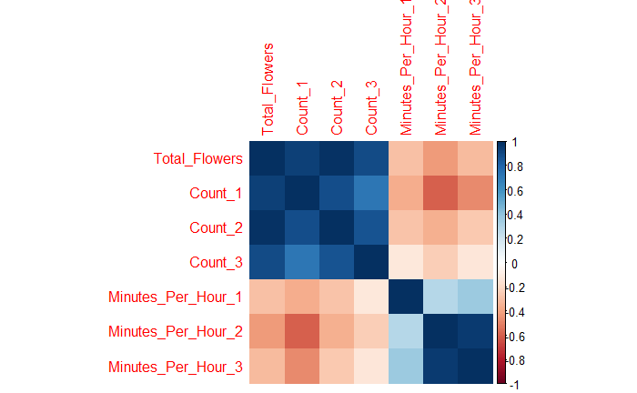

```r
correlations <- combined_data_region %>%
  select(Count, Region, Minutes_Per_Hour, Total_Flowers, Study_night) %>%
  pivot_wider(names_from = Region, values_from = c(Count, Minutes_Per_Hour)) %>%
  select(!Study_night) %>%
  cor(use = "complete.obs")

corrplot(correlations, method = "color")
```

This correlogram reveals a negative relationship between flower counts in a region and residence time in that region. However, kinkajous may be more attuned to flower density than flower count. We look at the same plot for density rather than count.

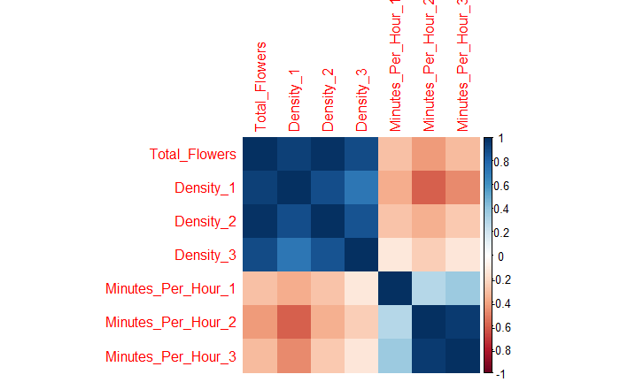

```r
correlations_proportion <- combined_data_region %>%
  select(Density, Region, Minutes_Per_Hour, Total_Flowers, Study_night) %>%
  pivot_wider(names_from = Region, values_from = c(Density, Minutes_Per_Hour)) %>%
  select(!Study_night) %>%
  cor(use = "complete.obs")

corrplot(correlations_proportion, method = "color")
```

This correllelation between flower density and residence time is also negative.

Next we consider how the density of flowers in a region, relative to other regions on the same night, guides kinkajou residence times. This measure removes the effect of total flower counts across the whole tree on residence time (which we know is negative from previous analysis) and focuses in on changes in nightly distributions.

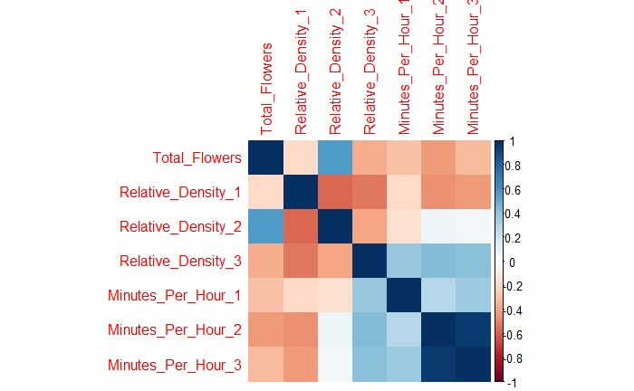

```r
correlations_proportion <- combined_data_region %>%
  select(Relative_Density, Region, Minutes_Per_Hour, Total_Flowers, Study_night) %>%
  pivot_wider(names_from = Region, values_from = c(Relative_Density, Minutes_Per_Hour)) %>%
  select(!Study_night) %>%
  cor(use = "complete.obs")

corrplot(correlations_proportion, method = "color")
```

The correlations between relative density and residence time are little more interesting. We see that when the density of flowers increases in region 3, residence times increase across all regions. Conversely, residence time in all regions is negatively correlated to the density in region 1. Looking back at the the relative densities across nights there is no clear temporal trend that could be driving this trend (along with decreasing kinkajou residence over the study). It also seems unlikely that the relative densities drive residence times across the whole tree - we would expect higher density in one regions to *decrease* residence time in other regions. We will need a formal model, however, to determine whether this trend falls outside the level of correlation we might expect by chance.

Finally, we consider whether the expected relative density (the average relative density across all previous nights) shapes residence times. This would reflect kinkajous relying more on previous information about the distribution of flowers to guide their behavior, and relying less on an ability to determine the actual distribution of flowers on a given night.

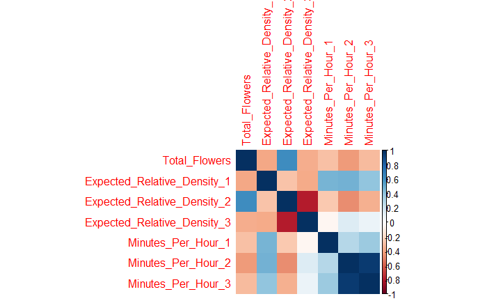

```r
correlations_proportion <- combined_data_region %>%
  select(Expected_Relative_Density, Region, Minutes_Per_Hour, Total_Flowers, Study_night) %>%
  pivot_wider(names_from = Region, values_from = c(Expected_Relative_Density, Minutes_Per_Hour)) %>%
  select(!Study_night) %>%
  cor(use = "complete.obs")

corrplot(correlations_proportion, method = "color")
```

Interestingly, the effects of expected relative density are largely opposite those from observed relative density. Greater expected relative density in region 1 increased residence time across all regions, while greater expected relative density in region 2 decreased residence time across all regions, and in region 3 it had little effect.

I don’t see an easy way to parse out these trends. The best explanation I can offer at this point is that expectations are inherently shaped by all preceding values. Thus high relative densities toward the start of the study might result in positive correlation between relative density and residence time and also lead to higher expected densities toward the end of the study, when residence times are generally lower (and thus a negative correlation between expected relative density and residence time). This leads to some questions about whether (and how) the structurally inherent temporal autocorrlation in expected relative density should be accounted for in a model.

### Bayesian methods

#### Region Density

We use a model to measure the impact of both total flowers in the tree and regional densities on kinkajou residence time. In addition to these two predictor variables, this model includes a fixed effect of each region on residence time. As of right now, this model uses default priors from get_prior, which are probably too wide.

```r
prior3 <- get_prior(Minutes_Per_Hour ~ Density + Region + Average_Density,
                                            data = combined_data_region,
                                            family = "gaussian")

residence_by_region_regression_model <- brm(Minutes_Per_Hour ~ Density + Region + Average_Density,
                                            data = combined_data_region,
                                            family = "gaussian",
                                            prior = prior3,
                                            warmup =1000, iter = 2000,
                                            refresh = 0)
save(residence_by_region_regression_model, file = "../Results/residence_by_region_MCMCs.Rdata")
summary(residence_by_region_regression_model)
```

[output not shown]

```r
load("../Results/residence_by_region_MCMCs.Rdata")
#Get predictions from each sample of the posterior for each night in the study
post_samples <- brms::as_draws_df(residence_by_region_regression_model)
names(post_samples)[c(1,3,4)] <- c("Region1", "Region2", "Region3") #Rename from Intercept for clarity
post_samples$Region2 <- post_samples$Region2 + post_samples$Region1 #convert estimates of Region 2 coefficient to intercept estimate for region 2
post_samples$Region3 <- post_samples$Region3 + post_samples$Region1 #convert estimates of Region 3 coefficient to intercept estimate for region 3
#determine and plot average predictions with 89% CIs
post_samples %>%
  pivot_longer(Region1:lp__, names_to = "Coefficient_Type", values_to = "Estimated_Effect") %>%
  filter(Coefficient_Type %in% c("Region1", "Region2", "Region3", "b_Average_Density", "b_Density")) %>%
  ggplot() +
  stat_density_ridges(aes(x = Estimated_Effect, y = Coefficient_Type), scale = 1, quantile_lines = TRUE, quantiles = c(0.055, 0.945)) + #the quantile lines on total flowers look wrong . . .
  geom_vline(xintercept = 0, color = "red", linetype = "dashed") +
  theme_classic() +
  #xlim(-10, 25) + #messes up quantile lines
  labs(title = "Posterior Distribution of Coefficients on Kinkajou-Minutes",
       x = "Estimate Effect",
       y = "Coefficient")
```

[output not shown]

#### Relative Region Density

Because region densities are very correlated with total flowers, it is probably better to use a predictor that normalizes the regional densities. Here, we get relative region densities by subtracting the density of flowers in the full tree from the density of flowers in each region on that night.

Having now explored some simple modelling approaches, we switch now to using the rethinking package to fully and explicitly parameterize this final model. The first thing this allows us to do is model the data using a zero-augmented gamma distribution, which is a mixture model that includes both a bernoulli distribution on the probability of observing a zero and a gamma distribution of the expected values when a zero is not observed. Thus, this model explicitly separates the effects any predictor variables have on kinkajous showing up, versus the amount of time kinkajous stay when they do show up. Final predictions in the posterior will account for the balance between both types of effects.

In addition to the predictor variables described, we take careful consideration in this model of co-variances, prior expectations, repeated measures, and varying effects.

```r
#bayesian methods


residence_by_region_relative_density_stan_fit <- map2stan(
  alist(
    Minutes_Per_Hour ~ dzagamma2(p, mu, scale),
    logit(p) <-  ap + ap_Region[Region] + bp_Average_Density * Average_Density + bp_Relative_Density * Relative_Density + ap_night[Study_night],    # logit link function for the bernoulli distribution on probability of observing a zero (no kinkajou residence)
    log(mu)  <-  am + am_Region[Region] + bm_Average_Density * Average_Density + bm_Relative_Density * Relative_Density + am_night[Study_night], # log link function for the mean (center?) of the gamme distribution on residence time, given a zero is not observed
    #priors below
    c(ap,am) ~ dnorm(0,2), #prior centers initial probability distribution of 0 residence time at 50% and residence time when a visit occurs at 1 minute.
    ap_Region[Region] ~ dnorm(0, ap_sigma_Region), #prior distribution on random effects of region (probability of 0)
    am_Region[Region] ~ dnorm(0, am_sigma_Region), #prior distribution on random effects of region (residence time given a 0 is not observed)
    ap_night[Study_night] ~ dnorm(0, ap_sigma_night), #prior distribution on random effects of night (probability of 0)
    am_night[Study_night] ~ dnorm(0, am_sigma_night), #prior distribution on reandom effects of night (residence time given a zero is not observed)
    c(bp_Average_Density,bm_Average_Density) ~ dnorm(0, 2), #prior distributions the coefficients for effects of average density (whole tree) on residence times (probablity of 0 and residence time given 0 is not observed)
    c(bp_Relative_Density,bm_Relative_Density) ~ dnorm(0, 2),   #prior distributions the coefficients for effects of relative density on residence times (probability of 0 and residence time given 0 is not observed)
    c(scale, am_sigma_night, ap_sigma_night, ap_sigma_Region, am_sigma_Region) ~ dexp(1) #prior distributions for variance parameters
  ),
  data = combined_data_region %>%
    select(Minutes_Per_Hour, Region, Relative_Density, Average_Density, Study_night) %>%
    na.omit() %>%
    mutate(Average_Density = as.numeric(Average_Density), Study_night = as.numeric(factor(Study_night))),
  cores=4 ,
  chains=4 ,
  warmup=1500,
  iter=3000,
  constraints=list(scale="lower=0")
)

save(residence_by_region_relative_density_stan_fit, file = "../Results/residence_by_region_MCMCs_relative_density.Rdata")
stancode(residence_by_region_relative_density_stan_fit)
```

```r
load("../Results/residence_by_region_MCMCs_relative_density.Rdata")
#Get predictions from each sample of the posterior for each night in the study
precis(residence_by_region_relative_density_stan_fit)
```

```
86 vector or matrix parameters hidden. Use depth=2 to show them.
```

|  | mean | sd | 5.5% | 94.5% | n_eff | Rhat4 |
| --- | --- | --- | --- | --- | --- | --- |
| ap | -2.39 | 1.36 | -4.53 | -0.19 | 2732 | 1.00 |
| am | 2.58 | 0.99 | 0.94 | 4.05 | 1466 | 1.00 |
| bp_Average_Density | 0.31 | 0.82 | -1.04 | 1.55 | 2526 | 1.00 |
| bm_Average_Density | -0.67 | 0.56 | -1.50 | 0.22 | 1830 | 1.00 |
| bp_Relative_Density | -0.67 | 1.64 | -3.27 | 1.95 | 4981 | 1.00 |
| bm_Relative_Density | 0.30 | 0.47 | -0.45 | 1.02 | 5264 | 1.00 |
| scale | 1.90 | 0.71 | 1.04 | 3.14 | 2662 | 1.00 |
| am_sigma_night | 0.91 | 0.30 | 0.54 | 1.42 | 2379 | 1.00 |
| ap_sigma_night | 0.65 | 0.60 | 0.05 | 1.77 | 245 | 1.02 |
| ap_sigma_Region | 0.66 | 0.66 | 0.06 | 1.87 | 863 | 1.01 |

[output cut: 1 more lines]

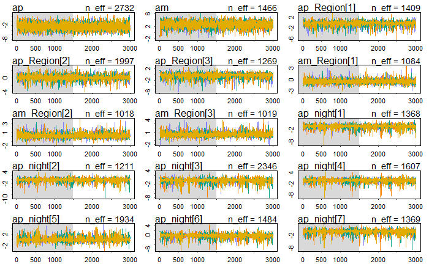

```r
plot(residence_by_region_relative_density_stan_fit)
```

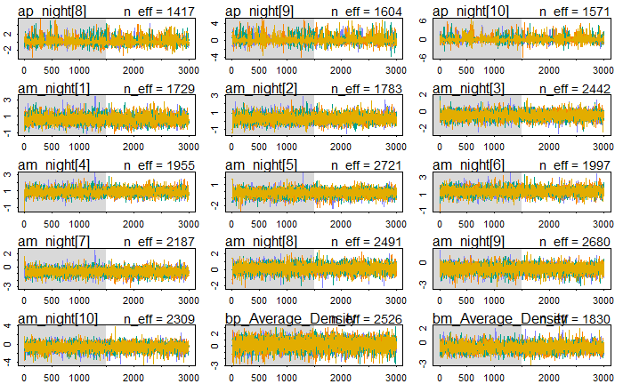

```r
NA
```

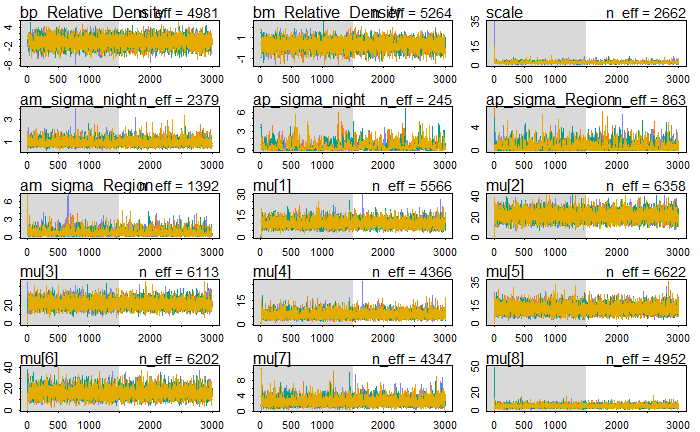

```r
NA
```

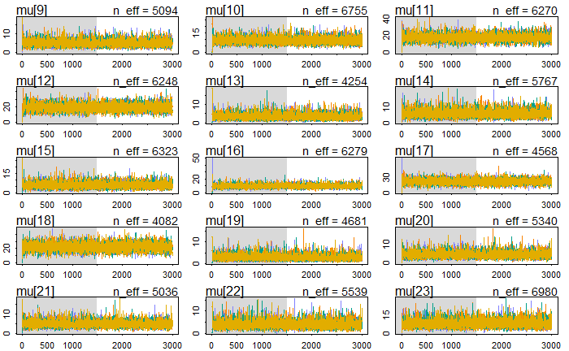

```r
NA
```

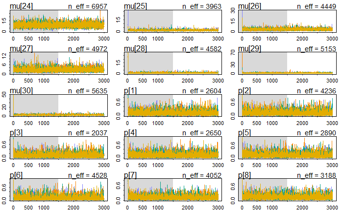

```r
NA
```

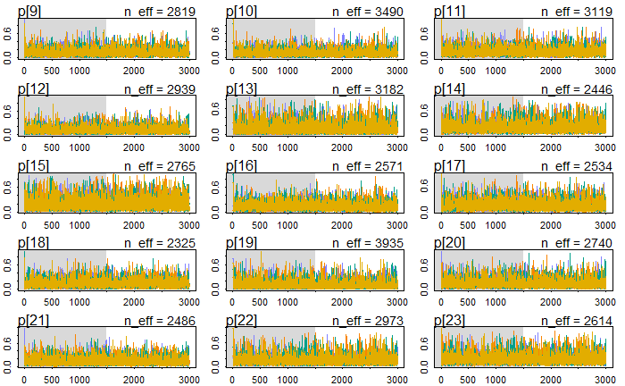

```r
NA
```

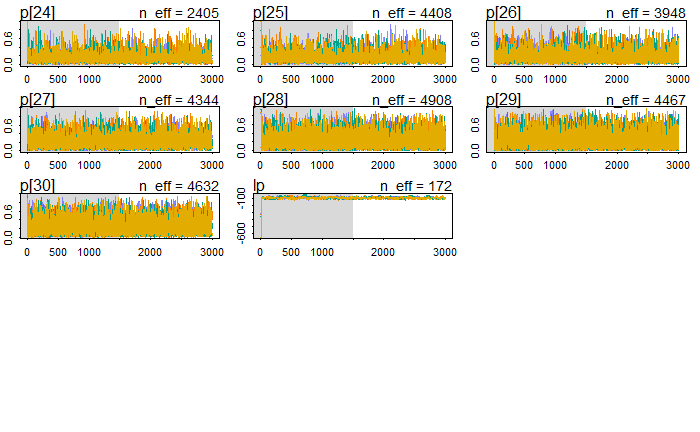

```r
NA
```

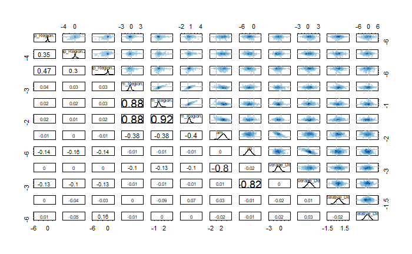

```r
pairs(residence_by_region_relative_density_stan_fit, pars = c("ap_Region", "am_Region", "am", "ap", "bm_Average_Density", "bp_Average_Density", "bm_Relative_Density", "bp_Relative_Density"))
```